# Clasificadores

*Víctor Bucheli Guerrero* *Universidad del Valle* *Octubre 25/ 2018*

En las regresiones lineales:

- La información es modelada para ajustarse a una línea.
- Usualmente usa el método del mínimo cuadrado para ajustarse a la línea.
- Usada para predecir valores continuos.

Los valores continuos pertenecen a una variable, por ejemplo:

Tenemos X que representa la velocidad de un carro en un momento dado y Y que representa el tiempo que toma detenerse dicho carro (X,Y). La regresión lineal sería usada para predecir el valor de Y para un X dado según un conjuto de datos.

```r
#Cargamos el dataset
data = read.csv("HombresMujeres.csv")
# Asignamos los nombres de las columnas
colnames(data) <- c("Nombre", "Genero", "Edad", "Peso", "Salario", "Riesgo", "Clase_A_Castillo", "Clase")
#data$Clase <- as.factor(data$Clase)
data
```

| Nombre | Genero | Edad | Peso | Salario | Riesgo | Clase_A_Castillo | Clase |
| --- | --- | --- | --- | --- | --- | --- | --- |
| María | F | 20 | 69 | 1000000 | 0,015037594 | no | 0 |
| Juana | F | 34 | 69 | 1100000 | 0,1210526316 | no | 0 |
| Camila | F | 57 | 52 | 1200000 | 0,2453720508 | si | 0 |
| Claudia | F | 44 | 51 | 1300000 | 0,1463091691 | no | 0 |
| Lorena | F | 43 | 53 | 1400000 | 0,1443826959 | no | 0 |
| María | F | 20 | 54 | 1500000 | 0,0129776496 | no | 0 |
| Jhoana | F | 40 | 65 | 1600000 | 0,1587830335 | no | 0 |
| Jimena | F | 46 | 97 | 1700000 | 0,2468866467 | si | 0 |
| Monica | F | 22 | 59 | 1800000 | 0,0267119411 | no | 0 |
| Claudia | F | 37 | 50 | 1900000 | 0,1141552511 | no | 0 |

[output cut: 19 more lines]

### Análisis Gráfico

Para realizar nuestra regresión lineal correctamente, establecer una relación lineal estadísticamente significativa, tenemos que entender como están distribuidos nuestros datos.

Antes de continuar vamos a definir dos conceptos, - respuesta: es la variable que queremos predecir, en general Y. - predictor: variable que nos da la información para predecir, en general X.

### Gráficando los datos

Cada persona representa un punto (xi, yi), en donde el eje X representa el Salario que tiene la persona y el eje y muestra si la persona es hombre o mujer (1 o 0 respectivamente). Pintamos la grafica diferenciando cada persona por su categoria (hombre o mujer):

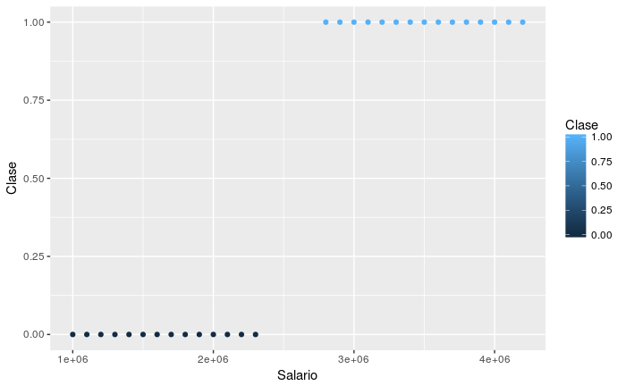

```r
require(ggplot2)
qplot(Salario, Clase, data = data, colour = Clase)
```

### Diagrama de cajas y bigotes

Mediante el diagrama de cajas y bigotes observamos los valores atípicos que pueden traer malos resultados.

```r
par(mfrow=c(1, 3))#Obtenemos las tres gráficas  en el mismo cuadro de respuesta.
boxplot(data["Edad"], main="Edad")  #Diagrama para "CaballosFuerza"
boxplot(data["Peso"], main="Peso")  #Diagrama para "CaballosFuerza"
```

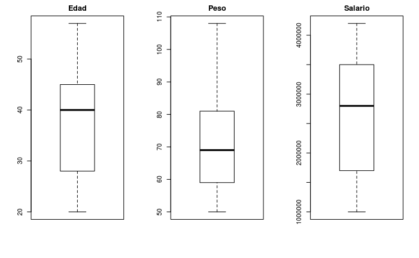

```r
boxplot(data["Salario"], main="Salario")  #Diagrama para "CaballosFuerza"
```

### Partir los datos en el conjunto de entrenamiento y de pruebas

Para el conjunto de entrenamiento se va a extraer el 70% de los datos del dataset, el otro 30% se va a usar para el conjunto de pruebas, se inicializa en la misma semilla para hacer el experimento reproducible.

```r
set.seed(1234) # semilla
muestra.cantidad <- floor(0.7 * nrow(data))
entrenamiento.index <- sample(seq_len(nrow(data)), size = muestra.cantidad)
conjunto_entrenamiento <- data[entrenamiento.index, ]
conjunto_prueba <- data[- entrenamiento.index, ]
```

### Modelo lineal

Podemos determinar la variable respuesta mediante la formula

#### *Y=β1+β2*X+ϵ*

Donde *β1* es el intercepto, *β2* es la pendiente, *X* es el valor conocido y *ϵ* es el término del error.

Tenemos que crear un modelo relacional y para eso vamos a utilizar la función lm.

```r
modeloLineal <- lm(Clase ~ Salario, data = data) #Usando el salario como predictor
summary(modeloLineal)
```

```
Call:
lm(formula = Clase ~ Salario, data = data)

Residuals:
     Min       1Q   Median       3Q      Max
-0.37955 -0.15521 -0.00768  0.15885  0.39612

Coefficients:
              Estimate Std. Error t value Pr(>|t|)
(Intercept) -6.524e-01  1.093e-01  -5.969 2.30e-06 ***
Salario      4.487e-07  3.907e-08  11.483 6.75e-12 ***
---
Signif. codes:  0 ‘***’ 0.001 ‘**’ 0.01 ‘*’ 0.05 ‘.’ 0.1 ‘ ’ 1

Residual standard error: 0.2135 on 27 degrees of freedom
Multiple R-squared:   0.83, Adjusted R-squared:  0.8237
F-statistic: 131.9 on 1 and 27 DF,  p-value: 6.755e-12
```

Con esto tenemos el intercepto y el valor de la pendiente. Parece que ya podemos proceeder a realizar nuestra predicción de valores, pero aún no es posible, antes de utilizar un modelo lineal tenemos que determinar si este es estadísticamente significativo.

Realizando un resumen estadístico de el modelo lineal podemos determinar varias cosas:

- p-value: Podemos encontrar el p-value general en la última linea y el p-value para cada predictor en la segunda línea abajo de Coefficients. El valor p-value es sumamente importante, porque podemos considerar un modelo lineal estadísticamente significativo sólo cuando los valores p-value sean menor al nivel estadístico de significancia, idealmente 0.05. Podemos observar visualmente esto con las estrellas al final de la fila, mayor número de estrellas más significante es la variable.
- R-Squared: Lo que R-Squared nos dice es la variación que hay en la variable respuesta.

Para el R-Squared y R-Squared Ajustado, mientras el valor más grande mejor es la significancia de nuestro modelo, para R-Squared se recomienda que sea un valor mayor a 0.7.

### Gráfico del diagnostico (modelo lineal)

Utilizamos el modelo para trazar la linea que divide a los datos.

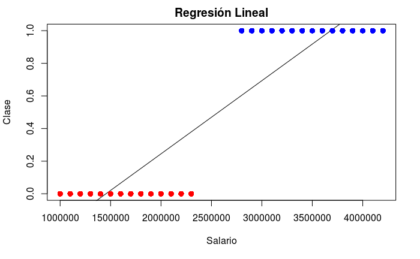

```r
colores <- ifelse(data[, "Clase"] == 1, "blue", "red") # Creamos los colores de los datos
plot(data[, "Salario"], data[, "Clase"], col = colores ,main = "Regresión Lineal", abline(modeloLineal),cex = 1.3,pch = 16,xlab = "Salario",ylab = "Clase")
```

### Predicción (usando modelo lineal)

Usamos el conjunto de pruebas y probamos el modelo. En la variable prediccion_lineal consta de 3 columnas, fit, lwr y upr. Utilizamos la columna fit que es el resultado de clasificar el conjunto de pruebas con el modelo.

```r
prediccion_lineal <-predict(modeloLineal, conjunto_prueba, interval = "prediction")
prediccion_lineal
```

```
          fit        lwr       upr
2  -0.1588521 -0.6205086 0.3028045
7   0.0654810 -0.3873415 0.5183035
8   0.1103476 -0.3411146 0.5618098
9   0.1552142 -0.2950263 0.6054548
19  0.7833468  0.3352477 1.2314459
23  0.9628133  0.5101866 1.4154399
24  1.0076799  0.5535744 1.4617853
25  1.0525465  0.5968259 1.5082670
28  1.1871463  0.7257779 1.6485147
```

### Matriz de confusión para las predicciones (lineal)

Una matriz de confusión es una herramienta que permite la visualización del desempeño de un algoritmo que se emplea en aprendizaje supervisado. Cada columna de la matriz representa el número de predicciones de cada clase, mientras que cada fila representa a las instancias en la clase real.

Convertimos a categoría el atributo “Clase” del conjunto de prueba para poder compararlo con las predicciones

```r
factor_prueba <- as.factor(conjunto_prueba[, "Clase"])
```

```r
library(caret)
pred_lineal <- as.vector(prediccion_lineal[, "fit"])
pred_lineal <- as.factor(ifelse(pred_lineal > 0.5, 1, 0)) # Cambiamos valores a 1s y 0s
# Creamos las matriz de confusión
confusionMatrix(factor_prueba, pred_lineal)
```

```
Confusion Matrix and Statistics

          Reference
Prediction 0 1
         0 4 0
         1 0 5

               Accuracy : 1
                 95% CI : (0.6637, 1)
    No Information Rate : 0.5556
    P-Value [Acc > NIR] : 0.005041

                  Kappa : 1
 Mcnemar's Test P-Value : NA

            Sensitivity : 1.0000
            Specificity : 1.0000
         Pos Pred Value : 1.0000
         Neg Pred Value : 1.0000
             Prevalence : 0.4444
         Detection Rate : 0.4444
   Detection Prevalence : 0.4444
      Balanced Accuracy : 1.0000

       'Positive' Class : 0
```

### Referencias

- http://r-statistics.co/Linear-Regression.html